# Computational Statistics Week 4

## Watrigant Timothée

#### Exercice 8.4

Pour cet exercice, commençons par créer des fonctions dont un pour l'algorithme de slice sampler, qui prend en entrée l'initailisation, le degré de l'exponentiel et le nombre d'itérations de l'algorithme de slice sampler. Les autres fonctions sont spécifiques à cet exercice, elles permettent de calculer la fonction de l'exercice ainsi que son inverse.

```r
f<-function(x,d) (exp(-(x^d)))

finv<- function(x,d) (-log(x))^(1/d)

slicesampler <- function(init,d,iterations){
  #initialisation
  x=rep(init,iterations)
  u=rep(init,iterations)
  for(i in 2:iterations){
   u[i]=runif(1,min=0,max=f(x[i-1],d))
   x[i]=runif(1,min=0,max=finv(u[i],d))
  }
  return(x)
}
```

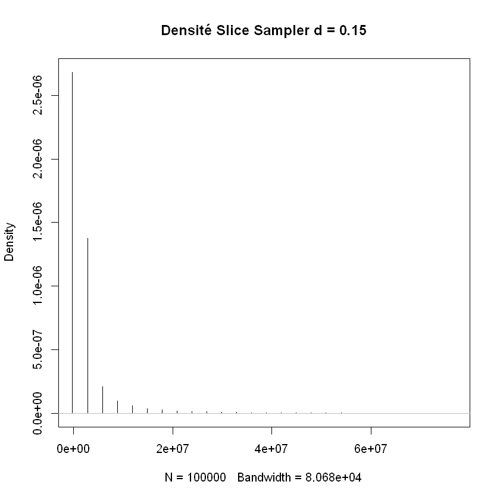

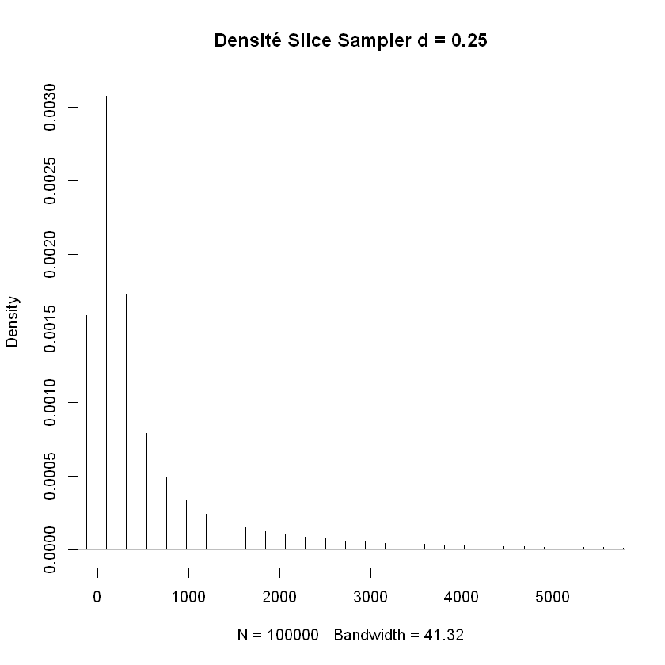

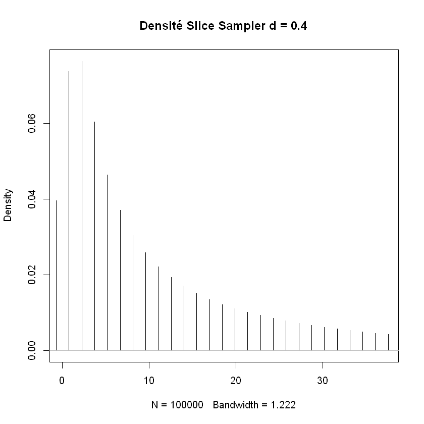

```r
dl=c(0.15,0.25,0.4)
for (d in dl){
  S = slicesampler(0,d,10^5)
  plot(density(S),type="h",xlim=c(0,0.05*max(S)),main=paste("Densité Slice Sampler d =",d))
}
```

On observe que plus le degré de l'exponentiel est petit, plus les chances d'avoir une valeur sont petites mais ont plus de valeurs possibles.

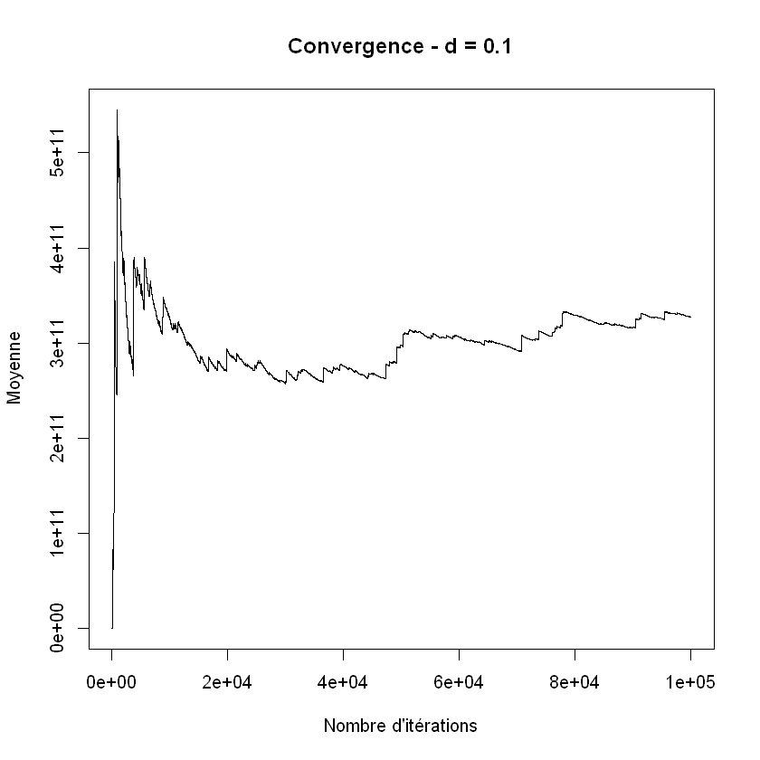

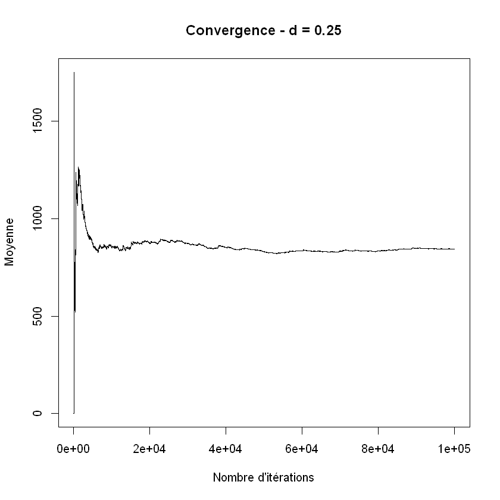

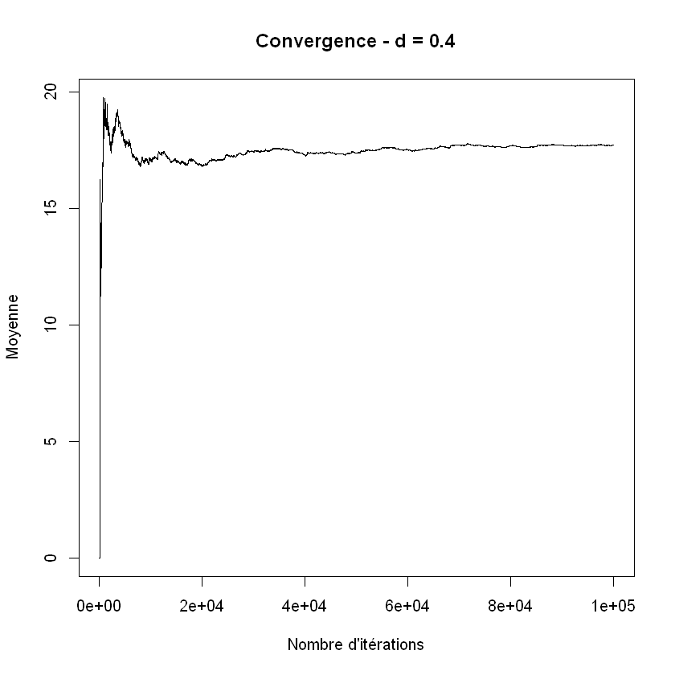

```r
d_list = c(0.1, 0.25, 0.4)
for (d in d_list) {
  X = slicesampler(0,d,10^5)
  plot(cumsum(X)/1:10^5, type = "l",
       main = paste("Convergence - d =", d),
       xlab = "Nombre d'itérations", ylab = "Moyenne")
}
```

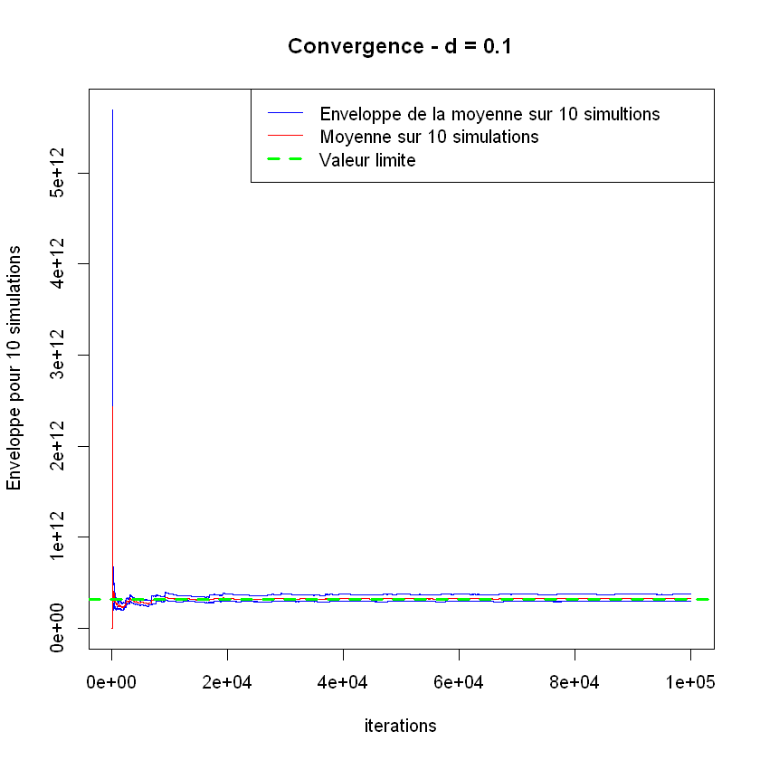

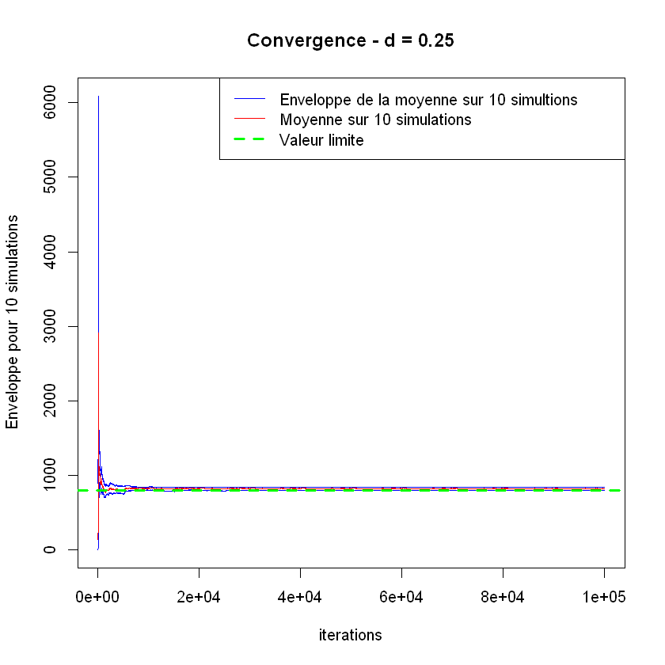

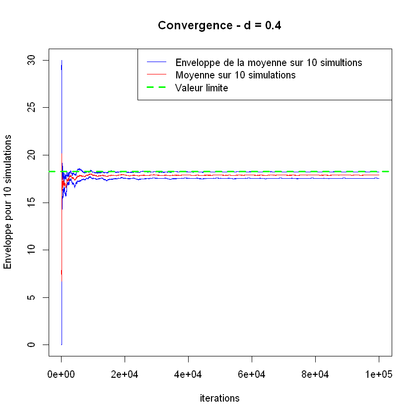

```r
for (d in d_list) {
  iterations=10^5
  X = slicesampler(0,d,iterations)
  simulations=10
  X1 = matrix(X,simulations,iterations)
  cummean_x=t(apply(X1,1,cumsum)/1:iterations)
  Min=apply(cummean_x,2,min)
  Max=apply(cummean_x,2,max)
  Mean=apply(cummean_x,2,mean)
  plot(1:iterations,Max,type="l",col="blue",ylim=c(0,max(Max)),main=paste("Convergence - d =", d),xlab="iterations",ylab="Enveloppe pour 10 simulations")
  lines(1:iterations,Min,col="blue")
  lines(1:iterations,Mean,col="red")
  abline(a=mean(slicesampler(0,d,iterations)),b=0,col="green",lw=3,lty=2)
  legend("topright",legend=c("Enveloppe de la moyenne sur 10 simultions","Moyenne sur 10 simulations","Valeur limite"),lwd=c(1,1,3),lty=c(1,1,2),col=c("blue","red","green"))
  }
```

On voit que dans chaque cas, on a une convergence vers la valeur limite. On pourrait croire que dans le dernier cas la convergence est moins bonne mais cela est dû au fait que l'axe des ordonnées est moins important que dans les deux autres cas.

#### Exercice 7.22

###### A

Le problème du vendeur est de pouvoir passer voir tous ces clients et revenir à son point de départ en faisant le chemin le plus court possible afin de pouvoir le maximum de clients en limitant le temps de trajet pour le vendeur.

Le problème est le même, puisque la distance minimale est inchangée et elle reste minimale, si on fait une permutation circulaire des clients à voir et du point de départ. Ainsi le point de départ n'a pas d'importance.

Le problème peut alors être formulé comme pour N clients signalés par un numéro, qui représente l'ordre dans lequel ils vont être visités, une permutation $\sigma$ entre deux clients et une distance parcourue (ou à parcourir) entre le client i et le client j:

- le vendeur part du point de départ 0
- puis va voir ses clients 1, 2, 3, ...,N
- puis il retourne au point de départ N+1=0
- à chaque étape, on regarde la distance entre chaque client que l'on somme afin calculer la distance totale que l'on cherche à minimiser

###### B

On cherche à minimiser la distance totale parcourue par le vendeur en considérant $\sigma$ comme les permutations possibles après le client i. On cherche à minimiser: $$H(\sigma) = \sum\limits_{i=0}^N (i,\sigma (i)) $$ Dans notre cas, on cherche bien à minimiser ce problème et non celui de minimiser à chaque étape la distance, qui permettrait de trouver l'ensemble des minima locaux mais ne certifie en rien que l'on aura le minimum global.

###### C

Dans la partie d'initialisation:

- repérer les clients (ici on va les repérer à l'aide de lois uniformes pour son abscisse et son ordonnée)
- calculer la matrice de distance entre les clients
- prendre de façon aléatoire un point de départ
- calculer la distance totale
- initialiser T

Dans la partie itérative:

- prendre 2 nombre entre 1 et N
- permuter l'ordre dans lequel le vendeur va voir ces clients représentés par leur nombre (qui sont les deux nombres choisis précédemment)
- calculer la nouvelle distance totale
- si la nouvelle distance est plus petite: on accepte cette permutation
- si la nouvelle distance est plus grande: on l'accepte avec une probabilité $\exp{\delta/T}$ (Metropolis-Hastings)
- mettre à jour T

###### D

On va maintenant implémenter ce problème, et voir la complexité du problème lorsque le nombre de clients augmente.

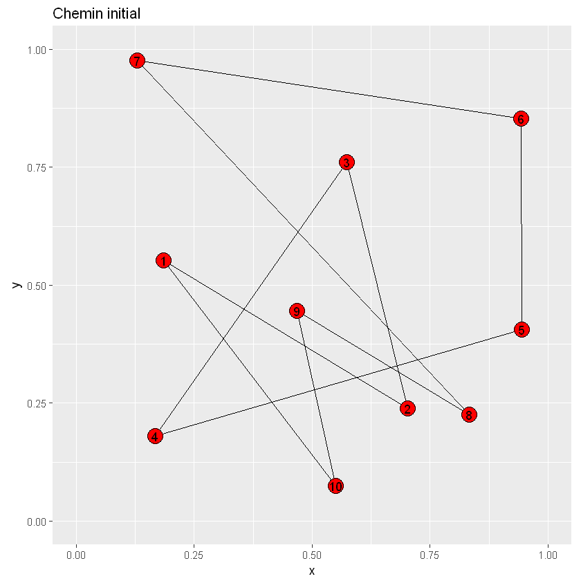

```r
set.seed(2)
library(ggplot2)

Nombre_clients = 10
T = 4
#génération des coordonnées de chaque client
x = runif(Nombre_clients)
y = runif(Nombre_clients)
clients = data.frame(x)
clients$y = y
sigma = seq(from = 1, to = Nombre_clients)

dist_matrix = as.matrix(dist(cbind(clients$x, clients$y)))
dist_current = function(clients, dist_matrix) {
  distance = 0
    for (i in 1:Nombre_clients) {
      distance = distance + dist_matrix[match(i, sigma),match(i %% Nombre_clients + 1, sigma)]
    }
  return(distance)
}

dist_permut = function(clients, dist_matrix){
    distance = 0
    for (i in 1:Nombre_clients) {
      distance = distance + dist_matrix[match(i, sigma_prop),match(i %% Nombre_clients + 1, sigma_prop)]
    }
  return(distance)
}

prob_accept = function(a, b, T){
  exp(-(b - a)/T)
}

clients$trip1 = sigma %% Nombre_clients %/% 2
clients$trip2 = (sigma + 1) %% Nombre_clients %/% 2

ggplot(clients, aes(x = x, y = y, label = sigma)) +   geom_line(data = clients, aes(group = trip1)) +
  geom_line(data = clients, aes(group = trip2)) +  geom_point(size = 6, shape = 21, fill = "red") +
  geom_text() +  coord_fixed(xlim = c(0,1), ylim = c(0,1)) +
  ggtitle("Chemin initial")
```

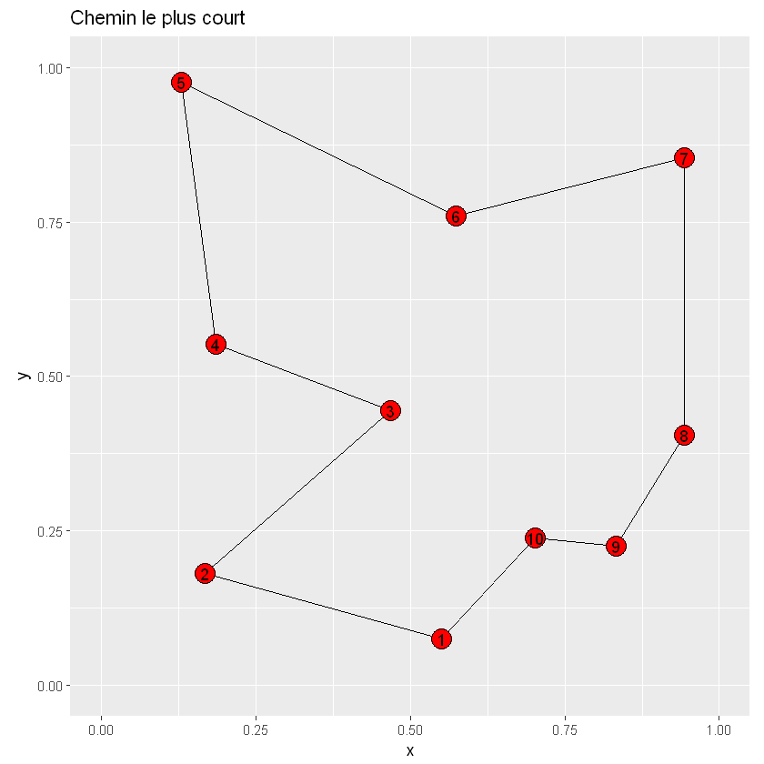

```r
d_actuel = dist_current(clients, dist_matrix)

iterations = 100000

best_dist = d_actuel
sigma_best = sigma
Dist<-c()
for (i in 1:iterations) {
  permut= sample(1:Nombre_clients, 2)

  sigma_prop = sigma
  sigma_prop[permut] = sigma_prop[rev(permut)]

  d_candidate = dist_permut(clients, dist_matrix)
  if (d_candidate <= d_actuel) {
    d_actuel = d_candidate
    sigma = sigma_prop
    if (d_actuel <= best_dist) {
      best_dist = d_actuel
      sigma_best = sigma
    }
  }
  else if (runif(1) < prob_accept(d_actuel, d_candidate, T)) {
    d_actuel = d_candidate
    sigma = sigma_prop
  }
  Dist[i]<-best_dist
  if (i %% 2500 == 0) {
    T = T * 0.7
  }
}

sigma = sigma_best

clients$trip1 = sigma %% Nombre_clients %/% 2
clients$trip2 = (sigma + 1) %% Nombre_clients %/% 2

ggplot(clients, aes(x = x, y = y, label = sigma)) +   geom_line(data = clients, aes(group = trip1)) +
  geom_line(data = clients, aes(group = trip2)) +  geom_point(size = 6, shape = 21, fill = "red") +
  geom_text() +  coord_fixed(xlim = c(0,1), ylim = c(0,1)) +
  ggtitle("Chemin le plus court")
```

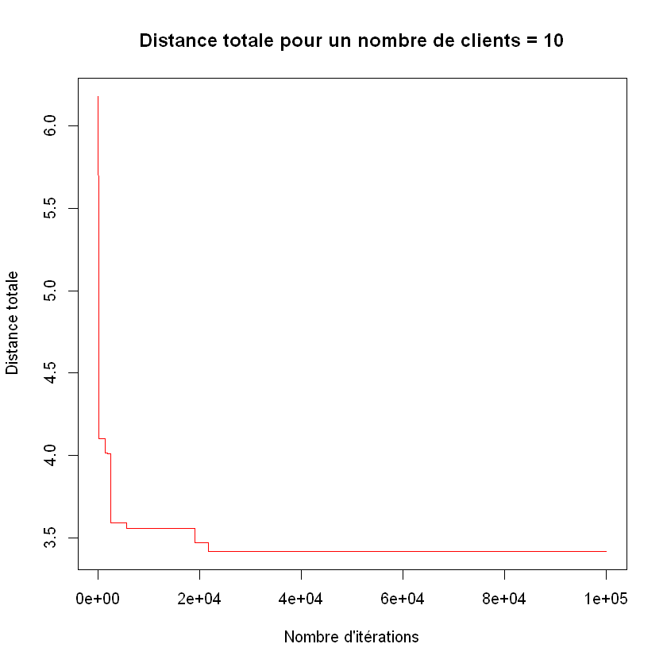

```r
plot(Dist,xlab="Nombre d'itérations",ylab="Distance totale",type="l",col="red",main = paste("Distance totale pour un nombre de clients =", Nombre_clients))
```

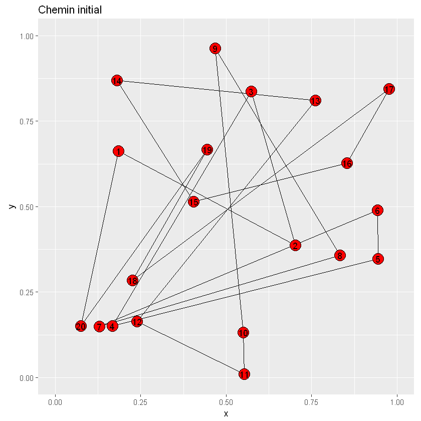

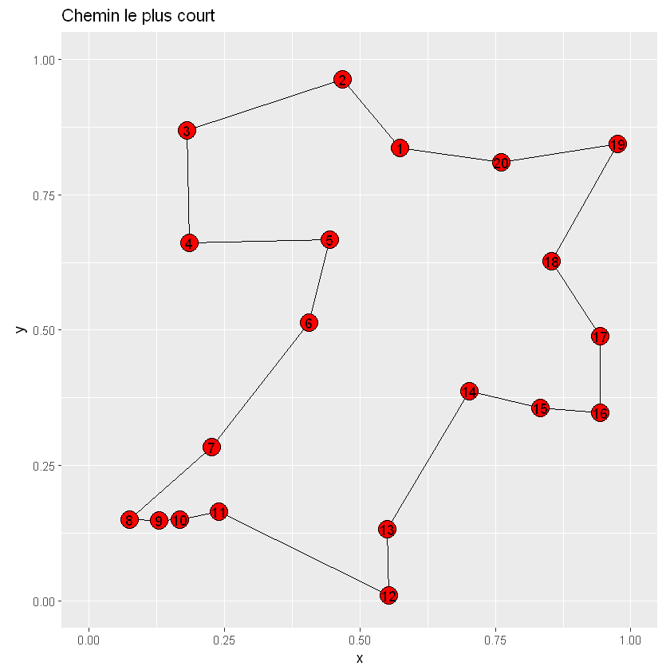

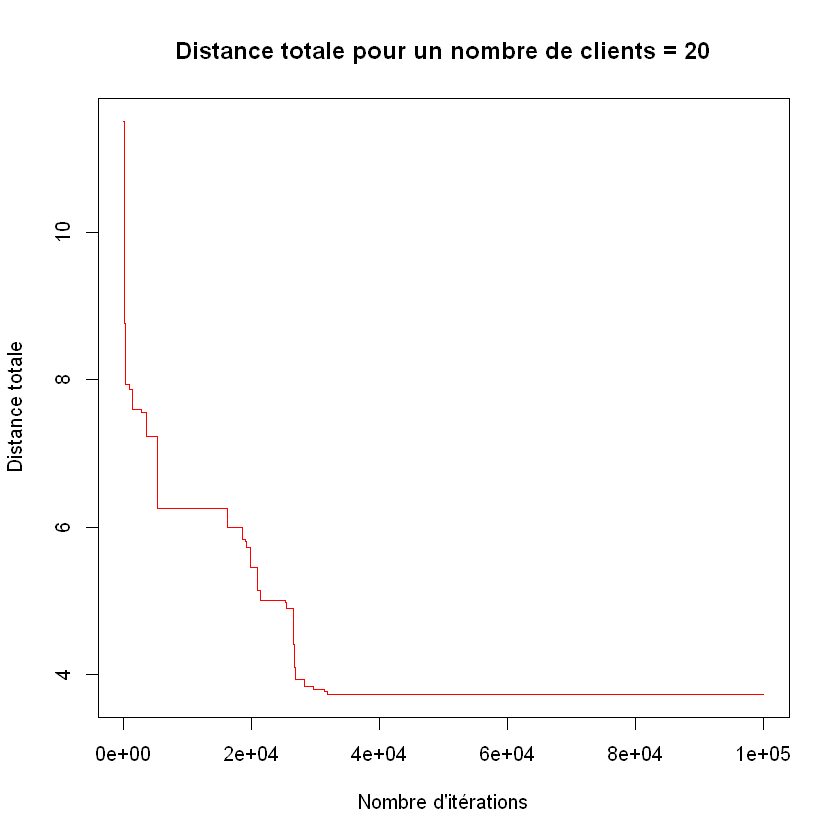

```r
set.seed(2)
library(ggplot2)

Nombre_clients = 20
T = 4
#génération des coordonnées de chaque client
x = runif(Nombre_clients)
y = runif(Nombre_clients)
clients = data.frame(x)
clients$y = y
sigma = seq(from = 1, to = Nombre_clients)

dist_matrix = as.matrix(dist(cbind(clients$x, clients$y)))
dist_current = function(clients, dist_matrix) {
  distance = 0
    for (i in 1:Nombre_clients) {
      distance = distance + dist_matrix[match(i, sigma),match(i %% Nombre_clients + 1, sigma)]
    }
  return(distance)
}

dist_permut = function(clients, dist_matrix){
    distance = 0
    for (i in 1:Nombre_clients) {
      distance = distance + dist_matrix[match(i, sigma_prop),match(i %% Nombre_clients + 1, sigma_prop)]
    }
  return(distance)
}

prob_accept = function(a, b, T){
  exp(-(b - a)/T)
}

clients$trip1 = sigma %% Nombre_clients %/% 2
clients$trip2 = (sigma + 1) %% Nombre_clients %/% 2

ggplot(clients, aes(x = x, y = y, label = sigma)) +   geom_line(data = clients, aes(group = trip1)) +
  geom_line(data = clients, aes(group = trip2)) +  geom_point(size = 6, shape = 21, fill = "red") +
  geom_text() +  coord_fixed(xlim = c(0,1), ylim = c(0,1)) +
  ggtitle("Chemin initial")

d_actuel = dist_current(clients, dist_matrix)


iterations = 100000

best_dist = d_actuel
sigma_best = sigma
Dist<-c()
for (i in 1:iterations) {
  permut= sample(1:Nombre_clients, 2)

  sigma_prop = sigma
  sigma_prop[permut] = sigma_prop[rev(permut)]

  d_candidate = dist_permut(clients, dist_matrix)
  if (d_candidate <= d_actuel) {
    d_actuel = d_candidate
    sigma = sigma_prop
    if (d_actuel <= best_dist) {
      best_dist = d_actuel
      sigma_best = sigma
    }
  }
  else if (runif(1) < prob_accept(d_actuel, d_candidate, T)) {
    d_actuel = d_candidate
    sigma = sigma_prop
  }
  Dist[i]<-best_dist
  if (i %% 2500 == 0) {
    T = T * 0.7
  }
}

sigma = sigma_best

clients$trip1 = sigma %% Nombre_clients %/% 2
clients$trip2 = (sigma + 1) %% Nombre_clients %/% 2

ggplot(clients, aes(x = x, y = y, label = sigma)) +   geom_line(data = clients, aes(group = trip1)) +
  geom_line(data = clients, aes(group = trip2)) +  geom_point(size = 6, shape = 21, fill = "red") +
  geom_text() +  coord_fixed(xlim = c(0,1), ylim = c(0,1)) +
  ggtitle("Chemin le plus court")

plot(Dist,xlab="Nombre d'itérations",ylab="Distance totale",type="l",col="red",main = paste("Distance totale pour un nombre de clients =", Nombre_clients))
```

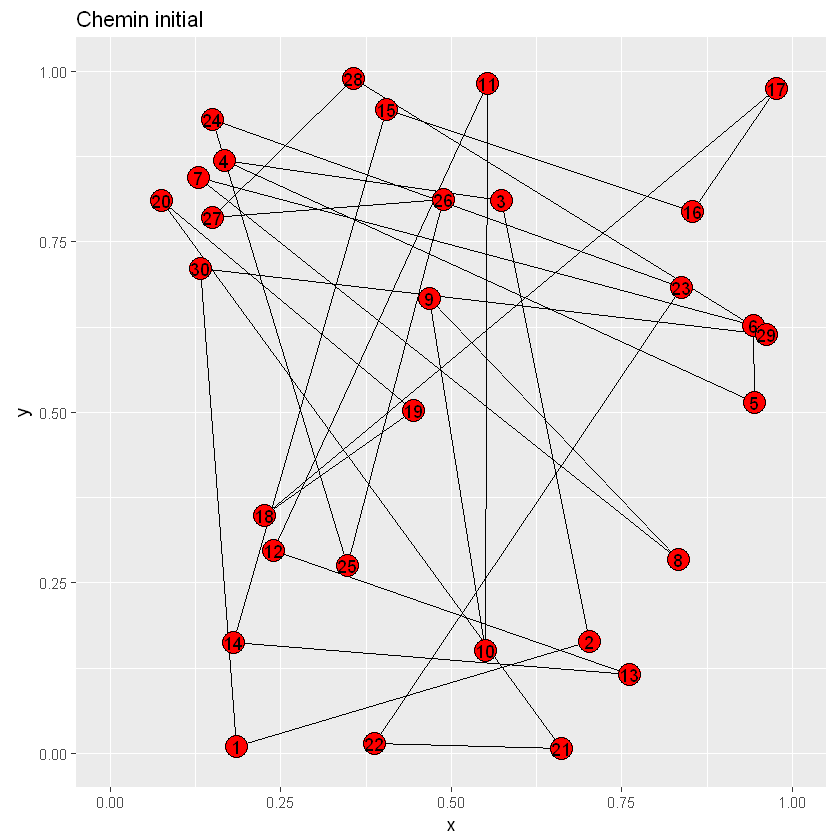

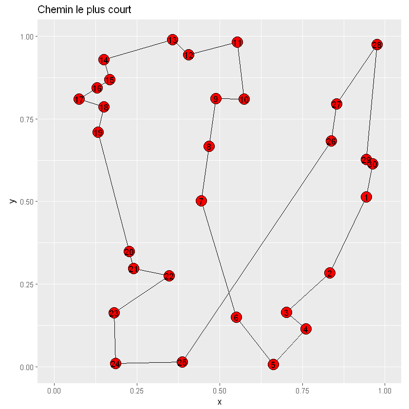

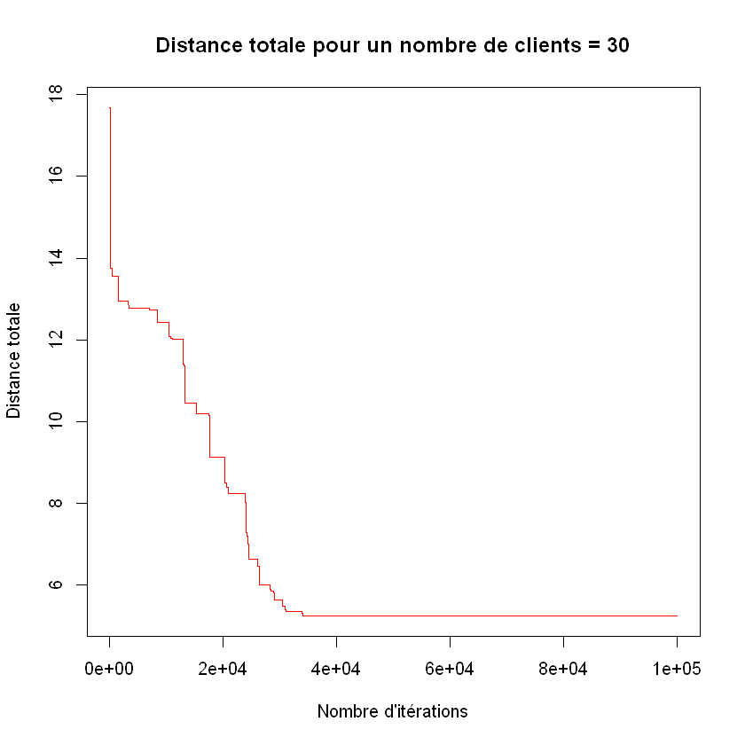

```r
set.seed(2)
library(ggplot2)

Nombre_clients = 30
T = 4
#génération des coordonnées de chaque client
x = runif(Nombre_clients)
y = runif(Nombre_clients)
clients = data.frame(x)
clients$y = y
sigma = seq(from = 1, to = Nombre_clients)

dist_matrix = as.matrix(dist(cbind(clients$x, clients$y)))
dist_current = function(clients, dist_matrix) {
  distance = 0
    for (i in 1:Nombre_clients) {
      distance = distance + dist_matrix[match(i, sigma),match(i %% Nombre_clients + 1, sigma)]
    }
  return(distance)
}

dist_permut = function(clients, dist_matrix){
    distance = 0
    for (i in 1:Nombre_clients) {
      distance = distance + dist_matrix[match(i, sigma_prop),match(i %% Nombre_clients + 1, sigma_prop)]
    }
  return(distance)
}

prob_accept = function(a, b, T){
  exp(-(b - a)/T)
}

clients$trip1 = sigma %% Nombre_clients %/% 2
clients$trip2 = (sigma + 1) %% Nombre_clients %/% 2

ggplot(clients, aes(x = x, y = y, label = sigma)) +   geom_line(data = clients, aes(group = trip1)) +
  geom_line(data = clients, aes(group = trip2)) +  geom_point(size = 6, shape = 21, fill = "red") +
  geom_text() +  coord_fixed(xlim = c(0,1), ylim = c(0,1)) +
  ggtitle("Chemin initial")

d_actuel = dist_current(clients, dist_matrix)


iterations = 100000

best_dist = d_actuel
sigma_best = sigma
Dist<-c()
for (i in 1:iterations) {
  permut= sample(1:Nombre_clients, 2)

  sigma_prop = sigma
  sigma_prop[permut] = sigma_prop[rev(permut)]

  d_candidate = dist_permut(clients, dist_matrix)
  if (d_candidate <= d_actuel) {
    d_actuel = d_candidate
    sigma = sigma_prop
    if (d_actuel <= best_dist) {
      best_dist = d_actuel
      sigma_best = sigma
    }
  }
  else if (runif(1) < prob_accept(d_actuel, d_candidate, T)) {
    d_actuel = d_candidate
    sigma = sigma_prop
  }
  Dist[i]<-best_dist
  if (i %% 2500 == 0) {
    T = T * 0.7
  }
}

sigma = sigma_best

clients$trip1 = sigma %% Nombre_clients %/% 2
clients$trip2 = (sigma + 1) %% Nombre_clients %/% 2

ggplot(clients, aes(x = x, y = y, label = sigma)) +   geom_line(data = clients, aes(group = trip1)) +
  geom_line(data = clients, aes(group = trip2)) +  geom_point(size = 6, shape = 21, fill = "red") +
  geom_text() +  coord_fixed(xlim = c(0,1), ylim = c(0,1)) +
  ggtitle("Chemin le plus court")

plot(Dist,xlab="Nombre d'itérations",ylab="Distance totale",type="l",col="red",main = paste("Distance totale pour un nombre de clients =", Nombre_clients))
```

Ici, on a un problème simplifié du vendeur puisque, dans la réalité, il y a également un problème sur le fait qu'il y ait une route de façon directe (en ligne droite) entre deux points consécutifs. Ici, on suppose que cette route existe toujours.